# RBIF 114 - Assignment 2

Jonathan Hummel

Last update: 30 April, 2024

# **Biomarker dataset**

## Aim and design

I found the data set that I used for this assignment when skimming a paper on candidate biomarkers for Type 1 Diabetes (T1D) during weeks 1 and 2 [1]. The authors of that paper re-analyzed a data set already listed in the Gene Expression Omnibus (GEO) to find genes differentially expressed in the pancreatic tissue of those with T1D and then narrowed in on a more promising subset by focusing on the ones that were central to various networks [1,2,3]. The original paper, cited in the GEO series page for [**GSE162689**](https://www.ncbi.nlm.nih.gov/geo/query/acc.cgi?acc=GSE162689), was more aimed at exploring the relationship between age, decline of insulin secretion, and diabetes, rather than explicit biomarker discovery, and the authors used samples from another GEO entry in addition to GSE162689 [2,3]. That said, this specific data set looked suitable for this assignment due to its design and the fact that another group already used it to discover potential biomarkers relevant to T1D [1,2]. The group that produced the data set also provided both the raw and normalized counts (TMM, CPM, and log using edgeR), as well as the FASTQs for each sample [3]. This enabled me to try processing the original RNA-seq data myself.

I mentioned above that the paper cited in the page for GSE162689 was focused on exploring the relationship between age and gene expression in pancreatic islet tissue to better understand the decline in insulin-secreting capabilities that occur with age, as well as T1D and diabetes in general [2]. That said, this specific dataset was only one of two that they used in that study [2,3]. From the description on GEO for GSE162689, it seems that this specific data set was *originally* generated as part of a study to histologically and transcriptionally characterize pancreatic tissue from donors with and without T1D, but was then repurposed for a different paper [3]. Specifically, they originally wanted to look at changes in the exocrine tissue of the pancreas, and for each donor, they sequenced a sample from the pancreatic islets (endocrine) as well as samples from tissue taken at 3 different distances from the islets (acinar/exocrine) [3]. Samples from these 4 tissue sources were taken from 7 deceased donors with T1D and 8 without [3]. Below is an overview table of all the samples, which I created from the run table on the SRA corresponding to GSE162689 [3,4]:

**Table 1**

All samples from GSE162689 (SRP295934). There were 4 sample types taken from 15 human donors. There are only 59 samples below, rather than 60, because one exocrine sample from the last donor failed basic quality checks [3]. All samples were taken from human pancreatic tissue and sequenced using an Ion Torrent S5 XL (single-read) [4]. Libraries were constructed for RNA-seq with AmpliSeq Transcriptome Human Gene Expression Kit (Thermo Fisher) [3]. Samples used in this assignment are highlighted in green.

| Run | Disease_State | Tissue |
| --- | --- | --- |
| SRR13199660 | non-diabetic | Islet tissue |
| SRR13199661 | non-diabetic | Exocrine tissue adjacent to islets (within 50 um from islets) |
| SRR13199662 | non-diabetic | Exocrine tissue at a distance between 50-100 um from islets |
| SRR13199663 | non-diabetic | Exocrine tissue far from islets (a minimum of 100 um from islets) |
| SRR13199664 | non-diabetic | Islet tissue |
| SRR13199665 | non-diabetic | Exocrine tissue adjacent to islets (within 50 um from islets) |
| SRR13199666 | non-diabetic | Exocrine tissue at a distance between 50-100 um from islets |
| SRR13199667 | non-diabetic | Exocrine tissue far from islets (a minimum of 100 um from islets) |
| SRR13199668 | non-diabetic | Islet tissue |
| SRR13199669 | non-diabetic | Exocrine tissue adjacent to islets (within 50 um from islets) |
| SRR13199670 | non-diabetic | Exocrine tissue at a distance between 50-100 um from islets |
| SRR13199671 | non-diabetic | Exocrine tissue far from islets (a minimum of 100 um from islets) |
| SRR13199672 | non-diabetic | Islet tissue |
| SRR13199673 | non-diabetic | Exocrine tissue adjacent to islets (within 50 um from islets) |
| SRR13199674 | non-diabetic | Exocrine tissue at a distance between 50-100 um from islets |
| SRR13199675 | non-diabetic | Exocrine tissue far from islets (a minimum of 100 um from islets) |
| SRR13199676 | non-diabetic | Islet tissue |
| SRR13199677 | non-diabetic | Exocrine tissue adjacent to islets (within 50 um from islets) |
| SRR13199678 | non-diabetic | Exocrine tissue at a distance between 50-100 um from islets |
| SRR13199679 | non-diabetic | Exocrine tissue far from islets (a minimum of 100 um from islets) |
| SRR13199680 | non-diabetic | Islet tissue |
| SRR13199681 | non-diabetic | Exocrine tissue adjacent to islets (within 50 um from islets) |
| SRR13199682 | non-diabetic | Exocrine tissue at a distance between 50-100 um from islets |
| SRR13199683 | non-diabetic | Exocrine tissue far from islets (a minimum of 100 um from islets) |
| SRR13199684 | non-diabetic | Islet tissue |
| SRR13199685 | non-diabetic | Exocrine tissue adjacent to islets (within 50 um from islets) |
| SRR13199686 | non-diabetic | Exocrine tissue at a distance between 50-100 um from islets |
| SRR13199687 | non-diabetic | Exocrine tissue far from islets (a minimum of 100 um from islets) |
| SRR13199688 | non-diabetic | Islet tissue |
| SRR13199689 | non-diabetic | Exocrine tissue adjacent to islets (within 50 um from islets) |
| SRR13199690 | non-diabetic | Exocrine tissue at a distance between 50-100 um from islets |
| SRR13199691 | non-diabetic | Exocrine tissue far from islets (a minimum of 100 um from islets) |
| SRR13199692 | type 1 diabetic | Islet tissue |
| SRR13199693 | type 1 diabetic | Exocrine tissue adjacent to islets (within 50 um from islets) |
| SRR13199694 | type 1 diabetic | Exocrine tissue at a distance between 50-100 um from islets |
| SRR13199695 | type 1 diabetic | Exocrine tissue far from islets (a minimum of 100 um from islets) |
| SRR13199696 | type 1 diabetic | Islet tissue |
| SRR13199697 | type 1 diabetic | Exocrine tissue adjacent to islets (within 50 um from islets) |
| SRR13199698 | type 1 diabetic | Exocrine tissue at a distance between 50-100 um from islets |
| SRR13199699 | type 1 diabetic | Exocrine tissue far from islets (a minimum of 100 um from islets) |
| SRR13199700 | type 1 diabetic | Islet tissue |
| SRR13199701 | type 1 diabetic | Exocrine tissue adjacent to islets (within 50 um from islets) |
| SRR13199702 | type 1 diabetic | Exocrine tissue at a distance between 50-100 um from islets |
| SRR13199703 | type 1 diabetic | Exocrine tissue far from islets (a minimum of 100 um from islets) |
| SRR13199704 | type 1 diabetic | Islet tissue |
| SRR13199705 | type 1 diabetic | Exocrine tissue adjacent to islets (within 50 um from islets) |
| SRR13199706 | type 1 diabetic | Exocrine tissue at a distance between 50-100 um from islets |
| SRR13199707 | type 1 diabetic | Exocrine tissue far from islets (a minimum of 100 um from islets) |
| SRR13199708 | type 1 diabetic | Islet tissue |
| SRR13199709 | type 1 diabetic | Exocrine tissue adjacent to islets (within 50 um from islets) |
| SRR13199710 | type 1 diabetic | Exocrine tissue at a distance between 50-100 um from islets |
| SRR13199711 | type 1 diabetic | Exocrine tissue far from islets (a minimum of 100 um from islets) |
| SRR13199712 | type 1 diabetic | Islet tissue |
| SRR13199713 | type 1 diabetic | Exocrine tissue adjacent to islets (within 50 um from islets) |
| SRR13199714 | type 1 diabetic | Exocrine tissue at a distance between 50-100 um from islets |
| SRR13199715 | type 1 diabetic | Exocrine tissue far from islets (a minimum of 100 um from islets) |
| SRR13199716 | type 1 diabetic | Islet tissue |
| SRR13199717 | type 1 diabetic | Exocrine tissue adjacent to islets (within 50 um from islets) |
| SRR13199718 | type 1 diabetic | Exocrine tissue far from islets (a minimum of 100 um from islets) |

As seen above there are 59 samples in total, but for this assignment, I decided to use only the endocrine/islet samples from all 15 individuals (highlighted in green). This was to keep things manageable while learning about RNA-seq pipelines. It also enabled a simple two-class, i.e. disease versus healthy, comparison of transcription levels in the analysis. That said, I may use the full data set for later assignments, as there are many exocrine tissue samples and I think they could provide useful information. I will note that there was some ambiguity for me about whether the 2 to 3 exocrine samples per patient are *effectively* technical replicates, even though I think they were originally intended as biologically distinct tissue samples [3]. From this point on, because I did not use them, I will not discuss or consider the exocrine samples above when going over the replicates, depth, power, etc. in order to keep things simple.

## Replicates

As outlined above, the original study design for this data set aimed to compare the gene expression profile in the endocrine (1 sample per patient) and exocrine (2-3 biologically distinct samples per patient) pancreatic tissue of 15 donors, including 7 with T1D and 8 without diabetes. Because I will only be comparing the *endocrine* T1D and non-diabetic samples in my analysis, there are effectively 7 biological replicates for T1D pancreatic endocrine tissue and 8 biological replicates for non-diabetic pancreatic endocrine tissue, with no technical replicates.

## Depth

The sequencing depth for these samples was a bit on the light side. The authors reported 7 to 13 million *mapped* reads per sample [2]. Overall, I had roughly comparable numbers. That said, during pseudoalignment to the transcriptome with Salmon, one sample stood out from the rest because it had a low mapping rate of about 47%. I will discuss this sample briefly in more detail in the section outlining the RNA-seq pipeline. Except for this one T1D sample, the Salmon mapping rates fell between 93.9% and 96.3% for effective depths of 5.9 to 10.1 million mapped reads per sample. The effective depth for the sample with a 47% mapping rate was 4.1 million mapped reads. So, on the whole, the effective depth of this data set is on the low end. Even so, the data set as I have processed it may be roughly passable assuming that 5 million mapped reads per sample is a reasonable minimum for differential gene expression [5]. At the same time, the statistical power may not be very high, which is discussed next.

## Statistical power

One of our assigned readings from week 2 made me aware of the R package called “RNASeqPower” [6], so I decided to use it to estimate the statistical power associated with my use of this RNA-seq data set. While statistical power is usually estimated ahead of time, here I had the luxury of already having a matrix of abundance values in TPM for all genes and samples, produced by the pipeline outlined later. Using this matrix, I could estimate things like the coefficients of variation for each group and the average/expected count per gene. With the help of the RNASeqPower documentation, I was able to write the following code which produces a plot of power estimates for this design/data set for a T1D versus non-diabetic differential gene expression analysis of the islet tissue samples [7]:

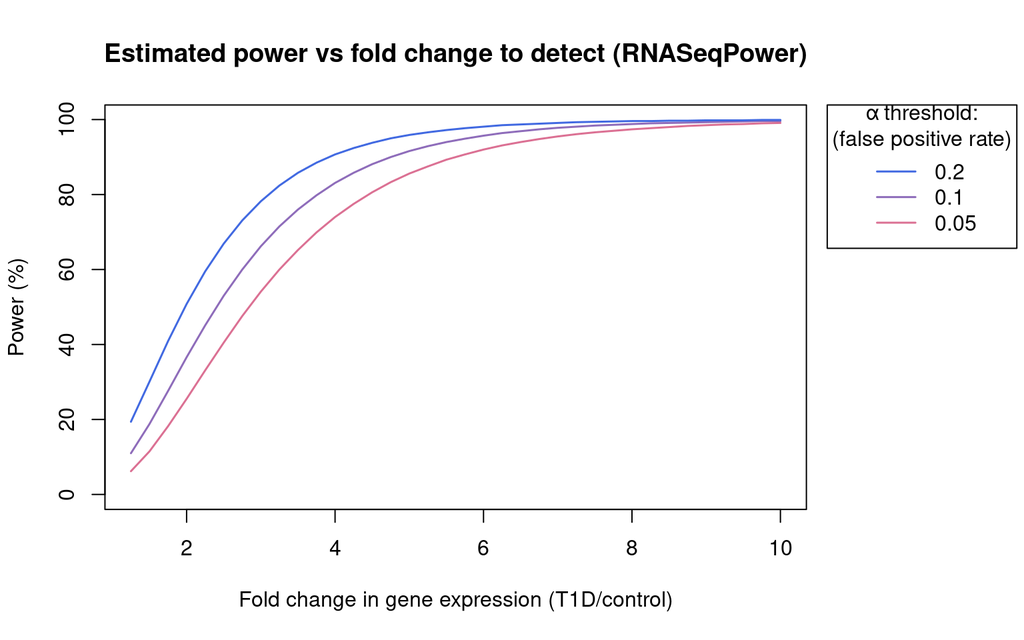

```r
library("RNASeqPower")
library("DESeq2")
library("kableExtra") # loaded for later

## Load the saved abundance information in TPM from tximeta/tximport (post Salmon quantification)
load(file="gene_summarized_experiment.sv")
abundance <- assays(gene_summarized_experiment)$abundance

## Get the accession numbers for the disease status groups from the sample table I made from SRA run table
samples_table <- samples_table <- read.csv("./Dataset1/SampleTable.csv")
samples_table$disease_state <- as.factor(gsub(" |-", "_", samples_table$disease_state))
non_t1db <- samples_table$names[samples_table$disease_state == "non_diabetic"]
t1db <- samples_table$names[samples_table$disease_state == "type_1_diabetic"]

## Crudely estimate the coefficient of variation (via s.dev/mean) for each group
## as well as the depth/expected count for any given gene, both via the TPM abundances
cv_1 <- rep(NA, dim(abundance)[1])
cv_2 <- rep(NA, dim(abundance)[1])
avg_abund <- rep(NA, dim(abundance)[1])
for (i.gene in 1:dim(abundance)[1]) {
  healthy <- abundance[i.gene, non_t1db]
  diabetes <- abundance[i.gene, t1db]
  cv_1[i.gene] <- sd(healthy) / mean(healthy)
  cv_2[i.gene] <- sd(diabetes) / mean(diabetes)
  avg_abund[i.gene] <- mean(abundance[i.gene,])
}
cv_1 <- mean(na.omit(cv_1))
cv_2 <- mean(na.omit(cv_2))

## Estimate the power for various alpha cutoffs and fold changes using RNASeqPower
power_estimates <- rnapower(depth=mean(na.omit(avg_abund)), # depth/expected count per gene
                            n=length(non_t1db), # N non-diabetes samples
                            n2=length(t1db), # N diabetes samples
                            cv=cv_1, # estimated non-diabetes coefficient of variation (~1)
                            cv2=cv_2, # estimated diabetes coefficient of variation (~1)
                            effect=seq(1.25,10,0.25), # fold changes in expression to detect
                            alpha= c(0.05,0.1,0.2)) # alpha thresholds/false positive rates accepted
power_estimates <- round(power_estimates, digits=3)*100

## Plot power estimation results
colpal <- colorRampPalette(c("palevioletred","royalblue"))
colorz <- colpal(length(colnames(power_estimates)))[rank(colnames(power_estimates))]
par(mfrow=c(1,1), cex=1, mar=c(5.1, 4.1, 4.1, 8.5))
plot(x=as.numeric(rownames(power_estimates)), y=power_estimates[,1],
     main="Estimated power vs fold change to detect (RNASeqPower)",
     xlab="Fold change in gene expression (T1D/control)",
     ylab="Power (%)",
     ylim=c(0, max(power_estimates)),
     type="l", col=colorz[1], lwd=1.5)
for (i in 2:length(colnames(power_estimates))) {
  lines(x=as.numeric(rownames(power_estimates)), y=power_estimates[,i], type="l", col=colorz[i], lwd=1.5)
}
legend("topright", inset=c(-0.3,0), xpd=TRUE, lty = 1, lwd = 1.5, col = rev(colorz), legend=rev(colnames(power_estimates)), title="α threshold:\n(false positive rate)")
```

As seen above, the estimated statistical power for this RNA-seq data set, given the T1D to non-diabetic gene expression comparison I intend to make, depends on both the chosen α threshold (false positive rate) and the fold change in expression that I would attempt to detect. It makes sense that the power scales with both factors. It is easier to detect greater fold changes in gene expression and not wrongly discount such genes. At the same time, one can increase the proportion of all truly differentially expressed genes detected by being less picky, but this also means allowing more false positives to get through. While only an estimate of the statistical power, the plot above gives me the impression that this design/dataset may be under-powered and could have benefited from greater sample sizes for both groups, as well as increased sequencing depth. The estimated power in the plot above is only ≥ 80% for detecting moderate to high fold changes in gene expression, i.e. roughly 3 to 5 and greater (depending on the α threshold). This may be important to keep in mind when considering the lists of apparently differentially expressed genes in the analysis later on. Also, from the RNASeqPower documentation, I believe the fold change in the plot above is of the typical “Condition<sub>B</sub> / Condition<sub>A</sub>” definition, with no log<sub>2</sub> or other transformations [7]. I tried to stick to using this version of fold change throughout the entire analysis, although some of the R documentation is not clear about this. It is also worth noting that when I refer to fold changes > 1 throughout this document, I mean both the corresponding increase (e.g. 3) and/or decrease (e.g. 1/3) fold change in gene expression, where applicable.

# **About the RNA-seq pipeline**

Although successfully doing our own RNA-seq pipeline on the raw FASTQ files was not necessary for this assignment, I was able to do so. The gene-level counts I will be using in the analysis and results section originate from my processing of the FASTQs submitted by *Granlund et al.* [2-4]. I will briefly show later that the genes found using the normalized counts from my pipeline overlap to a surprising extent with those obtained using the normalized counts submitted on GEO. That said, in future assignments, I will use their submitted matrix as a starting point now that I have determined that I can achieve vaguely comparable results on my own. For reference, I have provided a high-level overview of the pipeline below, citing helpful resources along the way and noting issues:

1. **Data Retrieval:** The SRA run table was used to get the SRR accession numbers for the 15 samples of interest [4]. The command line tools from the **SRA Toolkit** were then used to download the archive files and extract the FASTQs [8]. Bash was used to automate all of this.
2. **Quality Control:** I used **FastQC** and a Bash script to generate quality reports for all 15 FASTQs and then used **MultiQC** to aggregate all reports into one for easier consideration [9-11]. It was apparent that the quality in most reads became unacceptable toward the 3’ end, so **Trimmomatic** was used to trim the ends of reads once the average quality for a small sliding window dropped below 20 [12,13]. Reads below 25 bases in length were filtered out entirely. **FastQC** quality metrics for all samples were checked again via **MultiQC** after trimming and the intended quality outcome was confirmed. Overall, from what I could gather online, the other **FastQC** quality metrics were at least loosely passable given that they were for single-reads obtained using Ion Torrent technology, rather than Illumina. The only exception was the following:
   - *Odd GC Content Distribution:* Some GC spikes were protruding from the normal body of the GC content distribution plots for all samples. I used **SortMeRNA** to check the human rRNA content of all samples after quality trimming [14-16]. All samples had less than 0.5% of reads mapping to human rRNA, with most samples significantly lower than that, which seems consistent with successful rRNA depletion. That said, some other form of contamination seems plausible. I proceeded despite the odd GC content distributions under the assumption that it may have been due to primers or other synthetic sequences part of the library preparation and that these would not map to the transcriptome at high rates. I was not able to confirm this theory, because I could not find lists of such sequences from Thermo Fisher to check for, even with the kit names provided by *Granlund et al.* [3]. If this pipeline was not simply for learning purposes, further investigation would be needed.
3. **Quantification:** I used **Salmon** to map reads for all samples to the human transcriptome (GRCh38.p14) via pseudoalignment and calculate counts, abundances, and lengths for the transcripts [17,18]. Salmon usage was automated with a Bash script.
   - *Low Mapping Rate Sample:* As mentioned earlier, one T1D sample (SRR13199712) had a low read mapping rate of 47% during this step. That said, this sample appeared unremarkable in every other way. The total number of reads was similar to the other samples. I looked back at the individual **FastQC** report for this sample, as well as the report for all samples, and SRR13199712 was indistinct from the others by every quality metric provided. I could find no **FastQC** chart or table that differentiated this sample from all the others, which had mapping rates in the mid-90% range. The authors did not mention this sample as problematic in either the GEO entry or the cited paper [2,3]. Because I could not identify a clear reason to exclude this sample and because the T1D samples were already limited, I decided to continue with this sample included for now. Again, in a real setting further investigation would be necessary to justify using this sample.
4. **Aggregation to Genes:** I used **tximeta**, an extension of **tximport**, to import the values calculated by **Salmon** into R, in the form of a *SummarizedExperiment* object, and then summarize the transcript-level information from **Salmon** into gene-level matrices [18,19].
5. **Normalization:** I used **DESeq2** to first convert the gene-level *SummarizedExperiment* object created by **tximeta** into a *DESeqDataSet* object, then normalize the counts (median ratio method), and finally export the matrix of normalized counts [20-22]. These steps were done using the functions DESeqDataSet(*SummarizedExperiment*,…), estimateSizeFactors(*DESeqDataSet*), and counts(*DESeqDataSet*, normalized=TRUE) [20-22]. Before exporting the count matrix, genes with low values were filtered by including only those with ≥ 3 samples with ≥ 5 counts per gene [23].

# **Analysis and results**

The following is the code I wrote in RStudio to run the t-test (Welch’s/unpaired) to compare the mean expression in the T1D and non-diabetic groups for all genes, as well as calculate the adjusted p-values using the BH method. I did the t-test comparisons using the matrix of normalized counts obtained from the pipeline outlined in the last section (DESeq2’s median ratio method). The code below generated the plots and data discussed in the next two sub-sections:

```r
## Load the normalized counts (DESeq2 median ratio method), from the pipeline outlined earlier
load(file="normalized_counts.sv")

## Grab the T1D and non-diabetic sample numbers from a CSV I created from the SRA run table
samples_table <- samples_table <- read.csv("./Dataset1/SampleTable.csv")
samples_table$disease_state <- as.factor(gsub(" |-", "_", samples_table$disease_state))
non_t1db <- samples_table$names[samples_table$disease_state == "non_diabetic"]
t1db <- samples_table$names[samples_table$disease_state == "type_1_diabetic"]

## Get the names of genes from the count matrix
gene.names <- rownames(normalized_counts)

## Run loop to make T1D vs healthy t-test comparison for each gene
n.genes <- dim(normalized_counts)[1]
p.vals <- rep(NA, n.genes) # t-test p-values
fold.changes <- rep(NA, n.genes)
for (i.gene in 1:n.genes) {
  control <- normalized_counts[i.gene, non_t1db]
  disease <- normalized_counts[i.gene, t1db]
  p.vals[i.gene] <- t.test(control, disease)$p.value
  fold.changes[i.gene] <- mean(disease)/mean(control) # Classic B/A fold change (avg)
}
# Link the gene names, fold changes, and p-values for later filtering
genes.df <- data.frame(fold_change=fold.changes, p_value=p.vals, row.names = gene.names)

## Check the p-value distribution to make sure things look OK
hist(p.vals,
     main = "T-test p-values for T1D vs healthy gene expression\n(pancreatic islets)",
     xlab = "p-value (Welch's)")
abline(v=0.05, col='blue', lwd=2, lty=2)
abline(h=475, col='maroon', lwd=2, lty=3)
legend(x="topright",
       legend=c(paste("p < 0.05 : ",sum(p.vals<0.05)," genes",sep=""),
                "Crude uniform boundary (null genes)"),
       col=c("blue","maroon"),
       lwd=2,
       lty=c(2,3))

## Correct for multiple hypothesis testing with BH and plot adjusted vs raw
genes.df$BH_adjusted <- p.adjust(p.vals, method = "BH")
plot(rank(p.vals),
     genes.df$BH_adjusted,
     log = "y",
     main = "FDR/adjusted p-values vs raw p-value",
     ylab = "BH-adjusted p-value",
     xlab = "Rank")
# Explore the number of genes/q-values meeting certain FDR thresholds
abline(h=0.2,col="purple4",lty=2,lwd=2)
abline(h=0.1,col="royalblue",lty=2,lwd=2)
abline(h=0.05,col="forestgreen",lty=2,lwd=2)
legend(x="bottomright",
       legend=c(paste("FDR < 20% : ",sum(genes.df$BH_adjusted<0.2)," genes",sep=""),
                paste("FDR < 10% : ",sum(genes.df$BH_adjusted<0.1)," genes",sep=""),
                paste("FDR < 5% : ",sum(genes.df$BH_adjusted<0.05)," genes",sep="")),
       col=c("purple4","royalblue","forestgreen"),
       lty=2,
       lwd=2)

## Set alpha threshold and filter for apparently significant genes, pack into a list separated by up/down expressed
alpha <- 0.05
p.sig.genes <- list(descriptor = paste("T-test (Welch's) sig genes (alpha = ", alpha, ")", sep = ""),
                    up.genes = genes.df[genes.df$p_value < alpha & genes.df$fold_change > 1,],
                    down.genes = genes.df[genes.df$p_value < alpha & genes.df$fold_change < 1,],
                    all.genes = genes.df[genes.df$p_value < alpha,])
## Set FDRs and filter for apparently significant genes, pack into a list separated by up/down expressed
BH.sig.genes.5 <- list(descriptor = paste("BH adjusted sig genes (FDR = ", 0.05, ")", sep = ""),
                       up.genes = genes.df[genes.df$BH_adjusted < 0.05 & genes.df$fold_change > 1,],
                       down.genes = genes.df[genes.df$BH_adjusted < 0.05 & genes.df$fold_change < 1,],
                       all.genes = genes.df[genes.df$BH_adjusted < 0.05,])
BH.sig.genes.10 <- list(descriptor = paste("BH adjusted sig genes (FDR = ", 0.1, ")", sep = ""),
                        up.genes = genes.df[genes.df$BH_adjusted < 0.1 & genes.df$fold_change > 1,],
                        down.genes = genes.df[genes.df$BH_adjusted < 0.1 & genes.df$fold_change < 1,],
                        all.genes = genes.df[genes.df$BH_adjusted < 0.1,])
## Save results
save(p.sig.genes, file = "p.sig.genes.sv") # t-test p < 0.05
save(BH.sig.genes.5, file = "BH.sig.genes.5.sv") # BH FDR 5%
save(BH.sig.genes.10, file = "BH.sig.genes.10.sv") # BH FDR 10%
```

## T-test genes

The following is the histogram of p-values from the t-test comparisons of T1D to non-diabetic expression for all genes. I learned from RBIF 111 that looking at this distribution is usually a good idea to see that things seem OK:

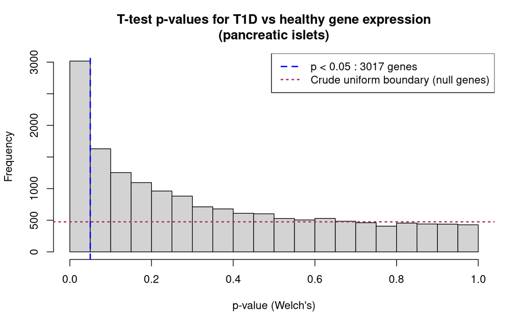

## BH-adjusted genes

The results of applying the Benjamini-Hochberg adjustment for multiple testing to the p-values produced from the Welch’s t-test earlier can be seen in the plot below, along with what happens when we choose different max false discovery rate (FDR) cutoffs (y-axis is log-scaled). The code that generated this plot was shown earlier:

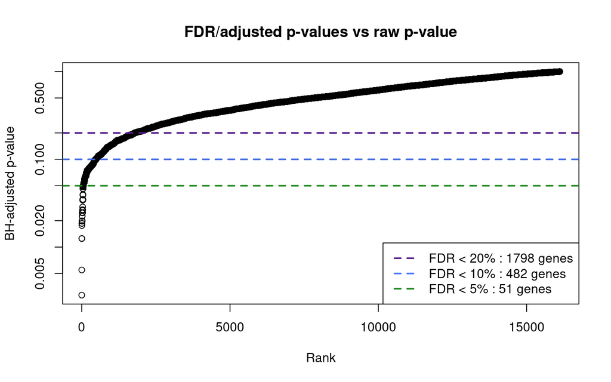

As seen above, using the BH method to correct for multiple hypothesis testing now results in fewer significant genes, the specific number of which depends on the max FDR that we want to tolerate. Using an FDR cutoff of 5% may be too stringent here, as 51 genes, representing ~48 true positives, is not many to start with. The estimation of power conducted earlier implies that this data set might not have adequate power to reliably detect fold changes too far below roughly 4 or 5. Filtering the genes by FDR < 5% would mean that ~6 or fewer genes would be left after filtering by > 3 or > 4 fold change (data not shown). As such, I will go with a more balanced (albeit risky) FDR threshold of 10% in order to have more genes left over after filtering by fold change, with the understanding that a higher proportion of them may be false positives. The the significant genes with a fold change ≥ 3 (increase or decrease), given an FDR < 10%, are shown in the table below (code not shown):

**Table 2**

The 148 significant genes with either a ≥ 3-fold increase or a ≤ 0.33-fold deacrese, sorted in descening order by fold change. The FDR was under 10% based on BH-adjusted p-values (~15 false positives at most). Fold change was calculated as mean(T1D)/mean(non-diabetic). The last two genes, highlighted in pink, had more than a 1/1e6 fold decrease and may have been outliers.

|  | fold_change | p_value | BH_adjusted |
| --- | --- | --- | --- |
| SLITRK6 | 9.1509421 | 0.0005634 | 0.0643685 |
| TENM1 | 7.0591561 | 0.0000354 | 0.0245692 |
| FRMD4B | 6.9017728 | 0.0015003 | 0.0812350 |
| SYNDIG1 | 6.5846259 | 0.0016672 | 0.0837597 |
| BRINP3 | 5.5792096 | 0.0009748 | 0.0754914 |
| DMD | 5.0441598 | 0.0013500 | 0.0799964 |
| ZNF587B | 5.0049211 | 0.0026452 | 0.0977880 |
| SCN9A | 4.9152122 | 0.0012175 | 0.0794503 |
| MAOB | 4.8518977 | 0.0002187 | 0.0533656 |
| LOC105374947 | 4.3770860 | 0.0001730 | 0.0506632 |
| WEE1 | 4.3635661 | 0.0000371 | 0.0245692 |
| NUP205 | 4.3617267 | 0.0013986 | 0.0802781 |
| CSGALNACT1 | 4.3506559 | 0.0007455 | 0.0703431 |
| SH3RF1 | 4.2126625 | 0.0029855 | 0.0999867 |
| CXCR4 | 4.1322253 | 0.0024639 | 0.0950426 |
| ADRA1A | 4.0769600 | 0.0028494 | 0.0985417 |
| POU5F1P4 | 4.0212954 | 0.0019298 | 0.0861603 |
| ABTB3 | 4.0201521 | 0.0019244 | 0.0861603 |
| FAP | 3.9182740 | 0.0000353 | 0.0245692 |
| GLS | 3.8551760 | 0.0004413 | 0.0617939 |
| SLC7A14 | 3.8355625 | 0.0008840 | 0.0751072 |
| RGS14 | 3.7840286 | 0.0022429 | 0.0902718 |
| PLIN5 | 3.7295625 | 0.0007692 | 0.0703704 |
| LINC01638 | 3.6545233 | 0.0010350 | 0.0754914 |
| LOC100507053 | 3.6454742 | 0.0010390 | 0.0754914 |
| SLC10A5 | 3.5665408 | 0.0012607 | 0.0798370 |
| LOC124901939 | 3.5489620 | 0.0017800 | 0.0851746 |
| CYP4F3 | 3.5304847 | 0.0002139 | 0.0533622 |
| A1CF | 3.4923253 | 0.0013837 | 0.0802245 |
| GPR37 | 3.4641882 | 0.0029169 | 0.0987698 |

[output cut: 118 more lines]

## Quick validation

Because I am using normalized gene counts from my own processing of the raw FASTQs, at this point in the analysis I was wondering how many of my apparently significant genes overlapped with those obtained using the researchers’ normalized counts provided on GEO [3]. I was curious whether the output of my pipeline work at least vaguely compared to theirs, even though this is a risky question to ask in bioinformatics! As a crude, check I ran the same analysis conducted in the last two sections, but instead using their counts provided on GEO in the “GSE162689_TMM_LG_220817.csv” file [3]. I know that these counts were CPM, TMM, and log normalized/transformed using edgeR [3], but I do not know much about the RNA-seq pipeline they used prior to that point besides the fact that they used an earlier version of the genome and/or transcriptome than I did (GRCh37.p13 vs GRCh38.p14) [4]. I will not show my code, as it is similar to code shown before, but makes used of R’s %in% operator to check for the significant genes that overlapped. The results of this comparison can be seen below:

**Table 3**

Comparison of signficant genes obtained via raw and BH-adjusted t-test p-values when using my normalized count matrix versus that of Granlund et al. [3]. Comparison of overlapping genes was made using the %in% operator with the vectors of gene names to determine the proportion of each set that overlapped the other.

| Method: | N sig. genes: theirs | N sig. genes: mine | Significant genes % overlap: theirs_in_mine | Significant genes % overlap: mine_in_theirs |
| --- | --- | --- | --- | --- |
| Raw p-values < 0.05 | 2874 | 3017 | 74.1 | 70.6 |
| BH, FDR < 5% | 79 | 51 | 50.6 | 78.4 |
| BH, FDR < 10% | 615 | 482 | 58.2 | 74.3 |

I was pretty surprised by the results shown above and had even to double-check the code. This is a better overlap in the genes identified as significant than I would have guessed, especially given that not only were different normalization methods used (DESeq2’s MRM versus edgeR’s TMM), but different RNA-seq pipelines were likely used before that. One could argue that me only finding ~50% of the significant that they would after using BH-adjusted p-values (FDR < 5%) is not great. That said, I think this is pretty good for different bioinformatics approaches. While this could be a fluke, to me it indicates that at least I did not completely botch the RNA-seq pipeline earlier, despite some issues that I could not explain and had to essentially ignore.

## SAM genes

The code I wrote in RStudio to run the SAM analysis on my normalized count matrix can be seen below, as well as its output. I was uncertain of whether it was best to use raw or normalized (and how?) counts with SAM-seq. I got fairly similar results regardless of what I used, but the curve looked less wonky using the same normalized counts from DESeq2 that I have used up until this point, so I went with that. I used 1000 permutations and 100 resamples during the analysis.

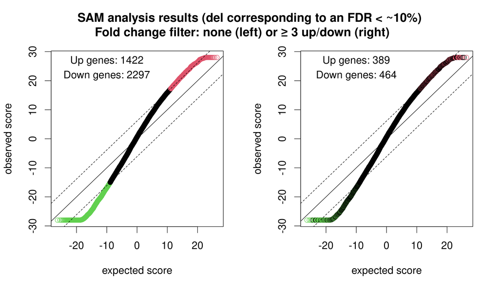

```r
library("samr")

## Load the normalized counts (DESeq2), from the pipeline outlined earlier
load(file="normalized_counts.sv")
counts <- round(normalized_counts) # Get the counts into integer numbers (not great practice!)

## Grab the T1D and non-diabetic status from a CSV I created from the SRA run table and convert to integer factors
samples_table <- samples_table <- read.csv("./Dataset1/SampleTable.csv")
disease_state <- as.integer(as.factor(gsub(" |-", "_", samples_table$disease_state)))

## Use RNA-seq wrapper for samr() to run SAM on the count data and group labels
samr_output <- SAMseq(counts,
                      disease_state,
                      genenames = rownames(counts),
                      resp.type = "Two class unpaired",
                      nperms = 1000,
                      nresamp = 100,
                      fdr.output = 0.1) # FDR of 10%, this determines del
save(samr_output, file="samr_output.sv")
# load("samr_output.sv")

## Plot the results of the SAM analysis (del set from output of the analysis for desired FDR)
par(mfrow=c(1,2), cex=1.5)
samr.plot(samr_output[[1]], del=as.vector(samr_output$del)) # don't filter by fold change for now
text(-10,25,c(paste("Up genes: ", samr_output$siggenes.table$ngenes.up, "\n", sep="")))
text(-10,20,c(paste("Down genes: ", samr_output$siggenes.table$ngenes.lo, "\n", sep="")))
samr.plot(samr_output[[1]], del=as.vector(samr_output$del), min.foldchange=3)
lo.sig.3fold <- samr_output$siggenes.table$genes.lo[as.numeric(samr_output$siggenes.table$genes.lo[,"Fold Change"])<=0.3333,]
hi.sig.3fold <- samr_output$siggenes.table$genes.up[as.numeric(samr_output$siggenes.table$genes.up[,"Fold Change"])>=3,]
text(-10,25,c(paste("Up genes: ", dim(hi.sig.3fold)[1], "\n", sep="")))
text(-10,20,c(paste("Down genes: ", dim(lo.sig.3fold)[1], "\n", sep="")))
mtext(expression(bold("SAM analysis results (del corresponding to an FDR ≈ 10%)\n    Fold change filter: none (left) or ≥ 3 up/down (right)")), side = 1, line = -21, outer = TRUE, cex=1.75)

## Save the significant genes from the SAM analysis for comparison to earlier results later
SAM.sig.genes.10 <- list(descriptor = paste("SAM-seq sig genes (FDR = ", 0.1, ")", sep = ""),
                         up.genes = as.data.frame(samr_output$siggenes.table$genes.up),
                         down.genes = as.data.frame(samr_output$siggenes.table$genes.lo))
SAM.sig.genes.10$all.genes <- rbind(genes.list.SAM$up.genes, genes.list.SAM$down.genes)
save(SAM.sig.genes.10, file="SAM.sig.genes.10.sv")

## Check out SAM's estimation of power given this data set's sample size
test.fold.changes <- seq(3,24,3) # assumed fold change for a truly differentially expressed gene
power.mat <- matrix(nrow = 10, ncol = length(test.fold.changes))
for (i in 1:length(test.fold.changes)) {
  FDR.m <- samr.assess.samplesize(samr.obj=samr_output[[1]],
                                  data=list(x=counts, y=disease_state),
                                  dif=test.fold.changes[i],
                                  samplesize.factors=c(1),
                                  min.genes=47, # Estimated from BH adjusted p-value minimum sig. genes for FDR = 5%
                                  max.genes=6443) # Estimated from (t-test) p-value histogram, max possible sig. genes (false negative right tail)
  FDR.m <- as.data.frame(FDR.m$results)
  power.mat[,i] <- 1 - FDR.m$"FDR,1-power" # calculate power from values provided from samr.assess.samplesize()
}
power.df <- as.data.frame(round(power.mat*100), row.names = FDR.m$"number of genes.1")
colnames(power.df) <- test.fold.changes

## Plot the power estimation results from SAM
colpal <- colorRampPalette(c("darkorange","royalblue"))
colorz <- colpal(length(test.fold.changes))[rank(test.fold.changes)]
par(mfrow=c(1,1), cex=1, mar=c(5.1, 4.1, 4.1, 7))
plot(x=as.numeric(rownames(power.df)), y=power.df[,1],
     main="Power vs number of true genes and fold change",
     xlab="Number of truly differentially expressed genes",
     ylab="Power % (SAM)",
     ylim=c(0, max(power.df)), type="l", col=colorz[1], lwd=1.5)
for (i in 2:length(test.fold.changes)) {
  lines(x=as.numeric(rownames(power.df)), y=power.df[,i], type="l", col=colorz[i], lwd=1.5)
}
legend("topright", inset=c(-0.23,0), xpd=TRUE, lty = 1,
       lwd = 1.5,
       col = rev(colorz),
       legend=rev(colnames(power.df)),
       title="Fold change:")
```

There are several interesting things about the results of the SAM analysis that can be seen above. The first of these is that using an FDR cutoff of 5% would have resulted in no genes with increased expression in the T1D group being detected as significant. This can be seen above by how close the significant genes with increased expression (top/red) are to the dashed line representing the “del” parameter used to filter genes, which is a function of the selected FDR threshold [24]. I am not sure why this asymmetry in significance between genes with increased and decreased expression exists, but it is interesting. Also interesting is the fact that, without fold change filtering, more genes were discovered as significant via SAM (3719) than using the raw t-test p-values (3017). This was surprising to me. Lastly, the plots above show the notable impact of imposing a fold change filter. As mentioned earlier, the initial power estimation for this experiment indicates that it is likely under-powered, especially with regard to detecting fold changes much lower than 4 or 5. Thus, imposing some sort of fold change filter is probably important, but this will notably diminish the number of candidate biomarker genes identified.

How many of the significant genes obtained earlier using the raw and BH-adjusted p-values line up with the genes represented in the plots above? The table below summarizes the answer to this question:

**Table 4**

Comparison of the significant genes identified by earlier methods to those identified by SAM (FDR under 10%). Comparisons are made for genes with no fold change filter applied and for those left after filtering by ≥ 3 fold change. Columns titled ‘x_in_SAM’ or ‘SAM_in_x’ refer to the percentage of signficant genes from a given method also found by SAM or vice versa.

| Method: | N_genes | No fold change filter: % overlap w/ SAM (N = 3719) x_in_SAM | No fold change filter: % overlap w/ SAM (N = 3719) SAM_in_x | N_genes. | ≥ 3 fold change (up/down): % overlap w/ SAM (N = 853) x_in_SAM. | ≥ 3 fold change (up/down): % overlap w/ SAM (N = 853) SAM_in_x. |
| --- | --- | --- | --- | --- | --- | --- |
| p-values < 0.05 | 3017 | 86.8 | 70.4 | 681 | 83.8 | 66.9 |
| BH, FDR < 10% | 482 | 100.0 | 13.0 | 148 | 97.3 | 16.9 |

As seen above, there is quite a bit of overlap between genes found as significant using the raw t-test p-values and SAM (FDR < 10%), particularly before any filtering by fold change is applied. While all or nearly all of the genes found using the BH-adjusted p-values (FDR < 10%) are also found by SAM (FDR < 10%), these represented only small a proportion of the total genes found by SAM with or without filtering. What is interesting about all of this is that SAM seems to be broad rather than restrictive, at least with regard to the number of genes it finds as significant in this specific data set. I was expecting this to be the other way around, with SAM either finding the fewest number of significant genes of any method, or finding a comparable amount to the BH-adjusted p-values. Because SAM relies on a sampling-based approach, this seems like a more robust way to identify a larger set of potential differentially expressed genes than using simple statistical tests. At some point I would like to see how the results from SAM compare to DESeq2, edgeR, limma, etc. The genes identified as significant by SAM with a fold change of 3 or greater in either direction can be seen below. A number of these genes at the extremes had fold changes that I considered to be questionable, i.e. well above a 1e6 fold increase or decrease, and they are highlighted in pink in the table:

**Table 5**

The 853 significant genes found with SAM (FDR under 10%) with either a ≥ 3-fold increase or a ≤ 0.33-fold deacrese, sorted in descening order by fold change. Genes that had a fold change in expression on the order of 1e6 or greater (up/down) were highlighted in pink, as they seem suspect and potentially represent experimental or normalization artifacts.

| Gene ID | Fold Change | q-value(%) |
| --- | --- | --- |
| ZNF718 | 19358713743.273 | 7.808 |
| TBC1D2B | 4778961424.897 | 8.693 |
| PDE4DIPP2 | 4686551245.382 | 9.977 |
| HLA-DQA2 | 2496193909.046 | 7.583 |
| LOC124905350 | 1741259967.236 | 6.806 |
| LINC02817 | 1209190773.101 | 6.593 |
| LOC105373950 | 1072828075.752 | 9.823 |
| H2BW4P | 1024270569.374 | 7.049 |
| CNTNAP4 | 998477564.218 | 9.711 |
| SOCS6 | 976364843.58 | 8.19 |
| TSPYL6 | 705361284.726 | 9.977 |
| LOC124906046 | 698934295.253 | 9.407 |
| CAPN6 | 693770380.06 | 9.873 |
| FABP12 | 663273548.167 | 10.012 |
| LINC01465 | 614562342.025 | 7.049 |
| LOC124904504 | 614562342.025 | 7.049 |
| LINC02324 | 585818906.548 | 6.996 |
| GPR52 | 585178950.865 | 8.938 |
| CXCL1 | 585178950.865 | 9.068 |
| TBC1D3G | 568520184.286 | 8.344 |
| ZNF275 | 499238782.609 | 6.593 |
| POU2AF2 | 499238782.609 | 6.593 |
| LOC101928868 | 499238782.609 | 7.032 |
| SLC8B1 | 495550271.757 | 8.251 |
| RPRM | 488182422.29 | 8.347 |
| LINC02080 | 487649125.887 | 8.509 |
| SLC9A7P1 | 487649125.887 | 8.637 |
| LOC107986557 | 473766820.405 | 8.594 |
| LOC105379091 | 409708228.35 | 8.594 |
| LOC124902188 | 409708228.35 | 9.299 |

[output cut: 823 more lines]

## SAM power estimation

While working on this assignment I found out that samr has a function called samr.assess.samplesize() for estimating the power associated with certain sample sizes from the output object of a SAM analysis. Because the earlier estimates I got with RNASeqPower implied that this data set may be under-powered, especially for detecting true fold changes in expression under 4 or 5, I figured it may be good to get another perspective on the estimated statistical power associated with using SAM on this data set. The plot below summarizes the results of the SAM power estimation. This plot was generated by the end of the code shown earlier for the SAM analysis. The power estimation is a function of several things including the sample size, expected number of truly differentially expressed genes, and the fold change we would like to detect. Since those latter two are either variable or uncertain, the estimation was run for a range of values. The minimum number of expected differentially expressed genes was estimated by the number of genes left after applying the BH-adjustment and an FDR threshold of 5%, minus the potential false positives (~47). I also could have just used zero for this value. The maximum number of differentially expressed genes was estimated by counting the total genes in the approximate *non-null* area of the p-value histogram shown earlier, i.e. the number of genes above the maroon line (6443). This provided a rough estimate of false negatives plus true positives.

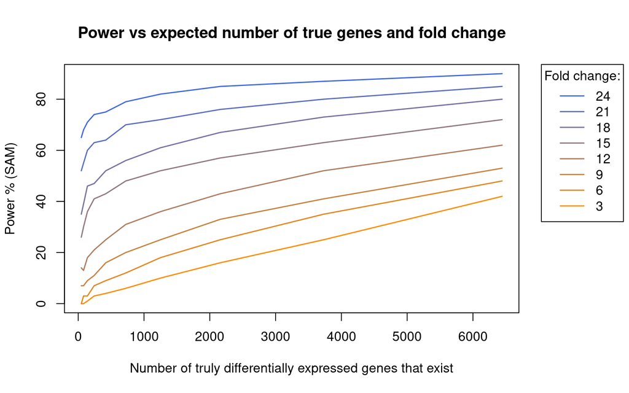

While this was just another way to estimate the power, which is complicated to do accurately for differential gene expression experiments, the plot above again makes me think that this experiment is most likely under-powered. The plot of estimated power shown earlier painted a more optimistic picture, and even that was not great for fold changes below 4 or 5. The plot above indicates that for this data set, using SAM is pretty under-powered for detecting all but the strongest changes in gene expression, assuming that the number of truly differentially expressed genes, i.e total positives, is on the upper end of the range I estimated. Based on the p-value histogram shown earlier, I believe this is actually a fair assumption, as it looks like there could be many false negatives, given superimposed null and non-null distributions. Based on the plot above, it seems that among those false negatives are many genes with moderate to low fold changes. This also may imply that the significant differentially expressed genes I found earlier with moderate to low values of fold change are enriched with false positives. This is because a notable proportion of total positives with moderate to low fold changes are likely hidden as false negatives. While I did my best, there is always the chance this power estimation was off due to user error. I could have misinterpreted the output table from samr.assess.samplesize(), because certain statistical terms/metrics were used interchangeably in ways that did not make sense to me, and the documentation was not much help in resolving these discrepancies.

While it may be under-powered, this design and data set are still likely capable of identifying some genes that are truly differentially expressed between the pancreatic endocrine tissue of T1D and non-diabetic donors. Among the 853 significant genes from SAM with fold changes ≥ 3 (up/down) in Table 5, roughly 87 had fold changes > 10 in either direction and roughly 45 had fold changes > 15 in either direction (FDR < 10%). This is after the extreme outliers are removed, i.e. the genes with over a 1e6 fold change mentioned earlier. So if we wanted to be really stringent and assume that all but the highest fold change genes are likely enriched with false positives due to an under-powered study, then there would still genes to look into! Also, even an under-powered study, as indicated by the plot above, can still identify truly differentially expressed genes in the lower fold change region. The results just need to be taken within the context of the low power, meaning that more of all low fold change genes may have been missed, and so the effective FDR for such genes may be higher than expected. If the list of differentially expressed genes was going to be investigated further by annotation-based analyses, or even additional experiments, then perhaps some of those extra false positives would simply be filtered out later.

# **References**

[1] Pujar, M., Vastrad, B., Kavatagimath, S., Vastrad, C., & Kotturshetti, S. (2022). Identification of candidate biomarkers and pathways associated with type 1 diabetes mellitus using bioinformatics analysis. In Scientific Reports (Vol. 12, Issue 1). Springer Science and Business Media LLC. https://doi.org/10.1038/s41598-022-13291-1

[2] Seiron, P., Stenwall, A., Hedin, A., Granlund, L., Esguerra, J. L. S., Volkov, P., Renström, E., Korsgren, O., Lundberg, M., & Skog, O. (2021). Transcriptional analysis of islets of Langerhans from organ donors of different ages. In M. G. von Herrath (Ed.), PLOS ONE (Vol. 16, Issue 3, p. e0247888). Public Library of Science (PLoS). https://doi.org/10.1371/journal.pone.0247888

[3] https://www.ncbi.nlm.nih.gov/geo/query/acc.cgi?acc=GSE162689

[4] https://www.ncbi.nlm.nih.gov/Traces/study/?acc=PRJNA682616

[5] https://www.ecseq.com/support/ngs/what-is-a-good-sequencing-depth-for-bulk-rna-seq

[6] Conesa, A., Madrigal, P., Tarazona, S., Gomez-Cabrero, D., Cervera, A., McPherson, A., Szcześniak, M. W., Gaffney, D. J., Elo, L. L., Zhang, X., & Mortazavi, A. (2016). A survey of best practices for RNA-seq data analysis. In Genome Biology (Vol. 17, Issue 1). Springer Science and Business Media LLC. https://doi.org/10.1186/s13059-016-0881-8

[7] https://bioconductor.org/packages/release/bioc/vignettes/RNASeqPower/inst/doc/samplesize.pdf

[8] https://www.ncbi.nlm.nih.gov/sra/docs/sradownload/

[9] https://www.bioinformatics.babraham.ac.uk/projects/fastqc/INSTALL.txt

[10] Ewels, P., Magnusson, M., Lundin, S., & Käller, M. (2016). MultiQC: summarize analysis results for multiple tools and samples in a single report. In Bioinformatics (Vol. 32, Issue 19, pp. 3047–3048). Oxford University Press (OUP). https://doi.org/10.1093/bioinformatics/btw354

[11] https://h3abionet.github.io/H3ABionet-SOPs/RNA-Seq-2-1.html

[12] https://h3abionet.github.io/H3ABionet-SOPs/RNA-Seq-2-2.html

[13] http://www.usadellab.org/cms/?page=trimmomatic

[14] https://github.com/sortmerna/sortmerna

[15] https://github.com/fallerlab/ARF/blob/main/rRNAs/4V6X_human_rRNAs.fa

[16] https://www.biostars.org/p/9523372/

[17] https://combine-lab.github.io/salmon/getting_started/

[18] https://bioconductor.org/packages/release/workflows/vignettes/rnaseqGene/inst/doc/rnaseqGene.html

[19] https://bioconductor.org/packages/release/bioc/vignettes/tximeta/inst/doc/tximeta.html

[20] Love, M. I., Anders, S., Kim, V., & Huber, W. (2016). RNA-Seq workflow: gene-level exploratory analysis and differential expression. In F1000Research (Vol. 4, p. 1070). F1000 Research Ltd. https://doi.org/10.12688/f1000research.7035.2

[21] https://hbctraining.github.io/DGE_workshop/lessons/02_DGE_count_normalization.html

[22] https://www.rdocumentation.org/packages/DESeq2/versions/1.12.3/topics/estimateSizeFactors

[23] https://support.bioconductor.org/p/65256/

[24] https://cran.r-project.org/web/packages/samr/samr.pdf